# Vinho Verde

Agata Kopyt

15 01 2022

# 1 Wstęp

Dokument przedstawia analizę eksploracyjną danych dotyczących portugalskich win “Vinho Verde”, pozyskanych z witryny [Kaggle](https://www.kaggle.com/uciml/red-wine-quality-cortez-et-al-2009). Zawiera omówienie zbioru danych oraz wstępną analizę jego zawartośći.

# 2 Omówienie zbioru danych

Pozyskany zbiór danych składa się z 12 kolumn oraz 1599 obserwacji:

- fixed.acidity - określa kwasy zawarte w winie stale lub nieulatniające się, w mg/L
- volatile.acidity - okresla ilość kwasu octowego w winie, który przy zbyt wysokim poziomie może prowadzić do nieprzyjemnego, octowego smaku, w g/L
- citric.acid - określa ilość kwasu cytrynowego, może dodać winom „świeżości” i smaku, w g/L
- residual.sugar - ilość cukru pozostała po zakończeniu fermentacji, w g/L rzadko można znaleźć wina o zawartości poniżej 1 g/L, a wina o zawartości powyżej 45 g/L są uważane za słodkie
- chlorides - określa ilość soli w winie, w g/L
- free.sulfur.dioxide - okresla ilość SO2 w formie wolnej, w ppm, zapobiega rozwojowi drobnoustrojów i utlenianiu wina
- total.sulfur.dioxide - okresla łączną ilość SO2 w formie wolnej, w ppm, w niskich stężeniach SO2 jest w większości niewykrywalny w winie, ale przy stężeniu wolnego SO2 powyżej 50 ppm, SO2 staje się widoczne w nosie i smaku wina
- density - określa gęstość wina w g/ml, jest zbliżona do gęstości wody w zależności od procentowej zawartości alkoholu i cukru
- pH - opisuje kwasowość lub zasadowość wina w skali od 0 (bardzo kwaśne) do 14 (bardzo zasadowe); większość win ma od 3 do 4 w skali pH
- sulphates - określa ilość siarczanów, które mogą przyczynić się do zwiększenia poziomu dwutlenku siarki (S02), działają jako środek przeciwdrobnoustrojowy i przeciwutleniacz
- alcohol - określa procent zawartości alkoholu w winie
- quality - zmienna wyjściowa (na podstawie danych sensorycznych, przyjmuje wartości od 0 do 10)

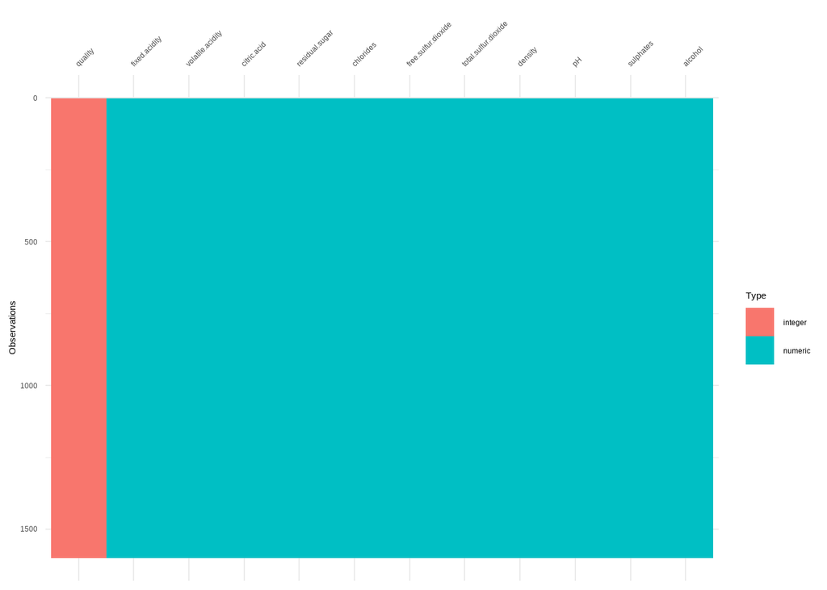

Na podstawie powyższego wykresu stwierdzam, że analizowane dane są wartościami liczbowymi. Poniższa tabela przedstawia najważniejsze informacje na temat każdej zmiennej.

| Zmienna | Liczba NA | Średnia | Odchylenie standardowe | Wartość minimalna | Wartość maksymalna | Unikalne wartości |
| --- | --- | --- | --- | --- | --- | --- |
| fixed.acidity | 0 | 8.3196373 | 1.7410963 | 4.60000 | 15.90000 | 96 |
| volatile.acidity | 0 | 0.5278205 | 0.1790597 | 0.12000 | 1.58000 | 143 |
| citric.acid | 0 | 0.2709756 | 0.1948011 | 0.00000 | 1.00000 | 80 |
| residual.sugar | 0 | 2.5388055 | 1.4099281 | 0.90000 | 15.50000 | 91 |
| chlorides | 0 | 0.0874665 | 0.0470653 | 0.01200 | 0.61100 | 153 |
| free.sulfur.dioxide | 0 | 15.8749218 | 10.4601570 | 1.00000 | 72.00000 | 60 |
| total.sulfur.dioxide | 0 | 46.4677924 | 32.8953245 | 6.00000 | 289.00000 | 144 |
| density | 0 | 0.9967467 | 0.0018873 | 0.99007 | 1.00369 | 436 |
| pH | 0 | 3.3111132 | 0.1543865 | 2.74000 | 4.01000 | 89 |
| sulphates | 0 | 0.6581488 | 0.1695070 | 0.33000 | 2.00000 | 96 |
| alcohol | 0 | 10.4229831 | 1.0656676 | 8.40000 | 14.90000 | 65 |
| quality | 0 | 5.6360225 | 0.8075694 | 3.00000 | 8.00000 | 6 |

Jak widać w zbiorze nie ma braków danych, a wartości zmiennych (oprócz zawartości dwutlenku siarki) oscylują wokół średniej. Warto zauważyć, że zmienna “quality” jest typu dyskretnego, zatem będę jej używać jako zmiennej typu dyskretnego. Z tabeli wynika również, że w zbiorze nie znajdują się wina słodkie.

# 3 Analiza danych

Zacznijmy od analizy rozkładu zmiennych “quality”, “alcohol” oraz “residual.sugar”

## 3.1 Rozkłady

### 3.1.1 Quality

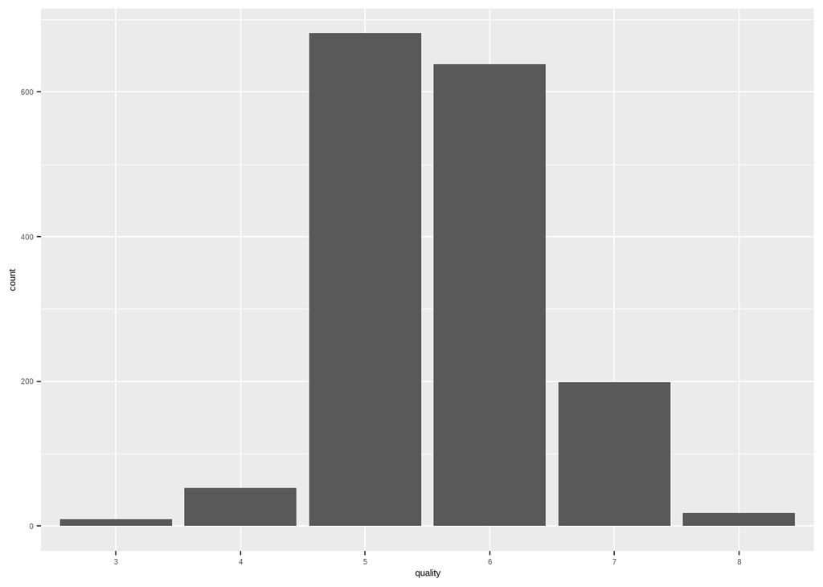

Wina nie są szczególnie zróżnicowane pod względem jakości, dominują wina przeciętne.

### 3.1.2 Alcohol

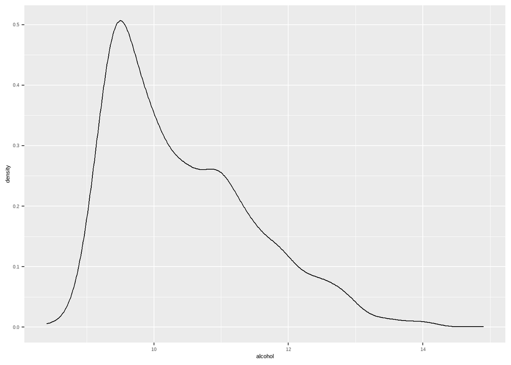

Przeważają wina o zawartości alkoholu ok. 9.5%. Znaczącą rolę w zbiorze pełnią też te o zawartości alkoholu ok. 11%.

### 3.1.3 Residual.sugar

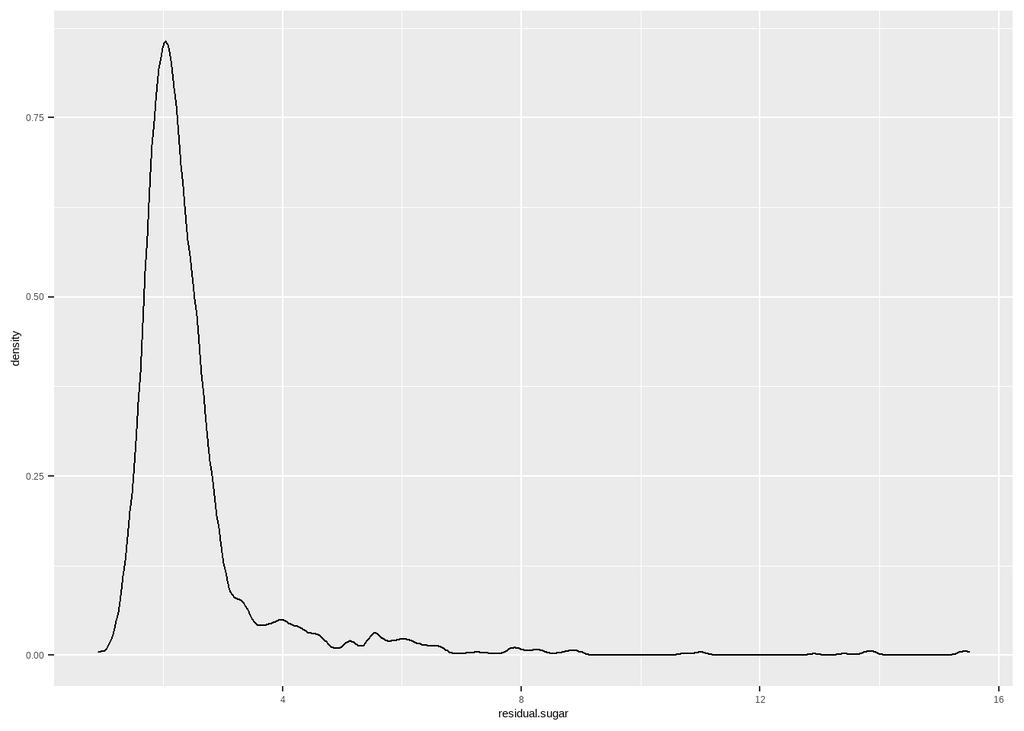

W zbiorze dominują wina o zawartości cukru ok. 2g/L. W zbiorze znajdują się też śladowe ilości win o większej słodkości. Wszystkie byłyby sklasyfikowane jako wytrawne.

## 3.2 Zależności

Wykres korelacji pomiędzy zmiennymi przedstawia się następująco:

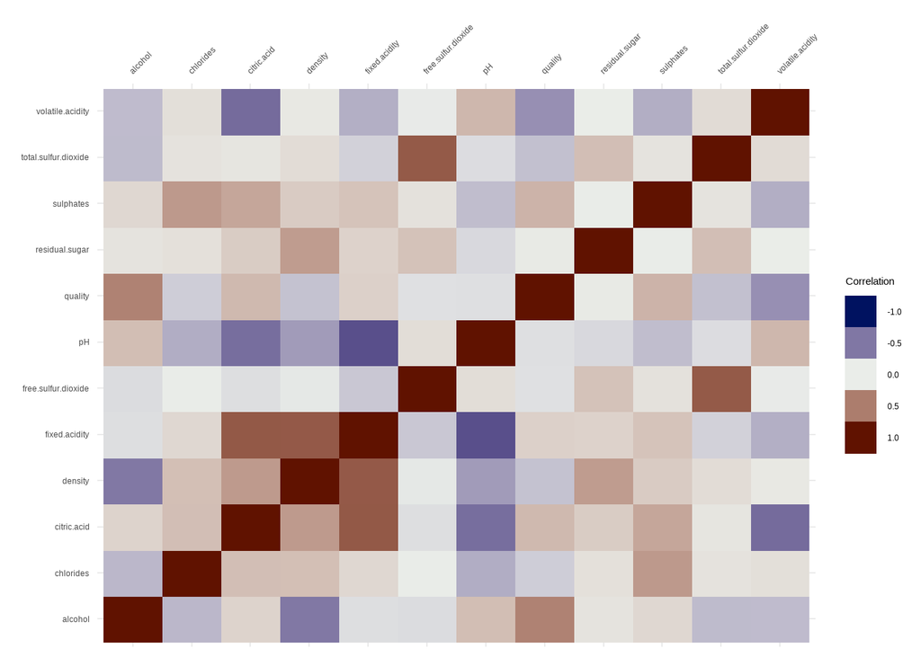

Większość korelacji wynika z chemicznych właściwości zmiennych, z tego powodu najbardziej interesujące są zależności zmiennych do jakości. Ponadto zbadam niektóre właściwości win ze względu na ich słodkość.

### 3.2.1 Quality vs Alcohol

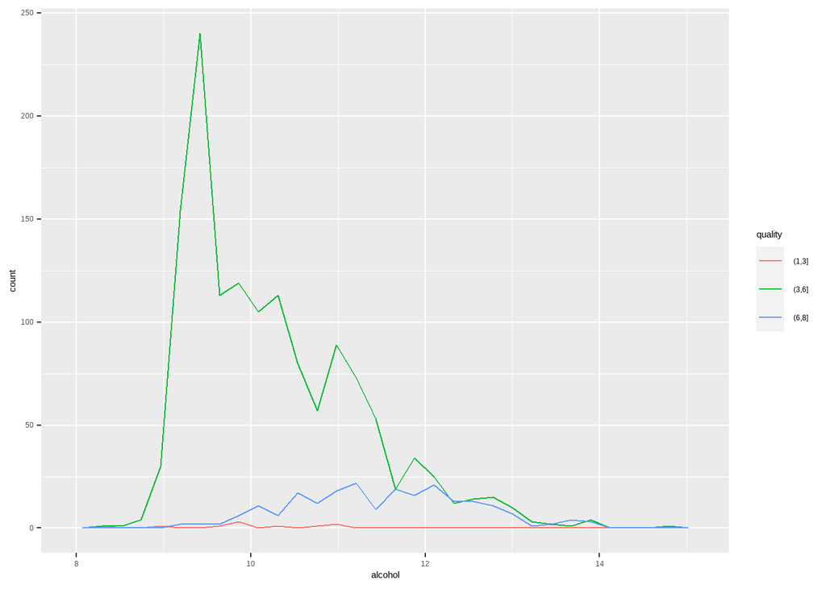

Analizując wykresy dla win lepszych (quality = 7,8), przeciętnych (quality = 4,5,6) oraz słabych (quality = 3),wynika, że lepsze jakościowo wina mają większą zawartość alkoholu. Należy jednak pamiętać, że reprezentacja “lepszych” win w tym zbiorze jest znacząco mniejsza od reprezentacji win “przeciętnych”.

### 3.2.2 Quality vs Sulphates

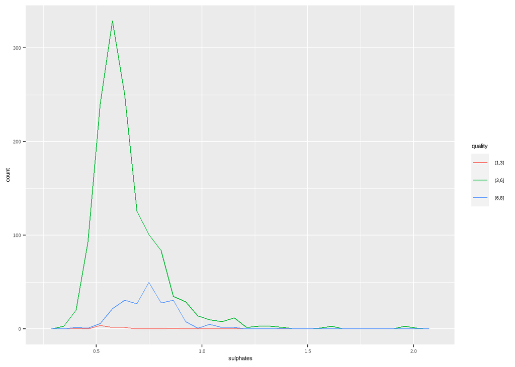

Z powyższego wykresu wynika, że lepsze jakościowo wina z analizowanego zbioru zawierają więcej siarczanów. Należy jednak pamiętać, że reprezentacja “lepszych” win w tym zbiorze jest znacząco mniejsza od reprezentacji win “przeciętnych”.

### 3.2.3 Residual.sugar vs Alcohol

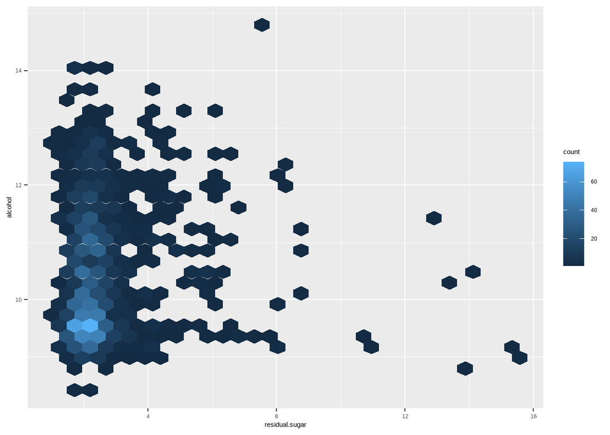

Zbiór danych zawiera najwięcej win o niskiej zawartości cukru i niskiej zawartości alkoholu. Zawartość alkoholu jest najbardziej zróżnicowana dla win o mniejszej słodkości. Zawartość cukru jest najbardziej zróżnicowana dla win o mniejszej zawartości alkoholu. Z wykresu wynika, że w większości przypadków wina o większej zawartości alkoholu są mniej słodkie.

### 3.2.4 Residual.sugar vs Sulphates

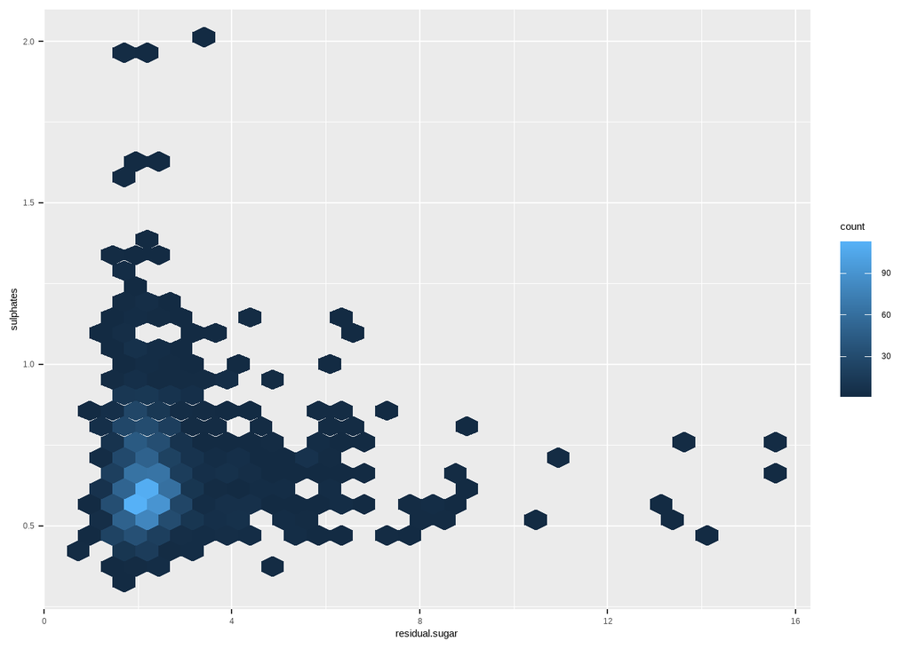